# HW2_3_course

Elizaveta Udalova

2026-02-23

# Individual project: Exploratory factor analysis

```r
library(foreign)
library(corrplot)
library(ggplot2)
library(lavaan)
library(tidyr)
library(psych)
library(dplyr)
library(nFactors)
library(knitr)
library(kableExtra)
```

### 1. Filtering data and removing NAs

```r
ess <- read.csv('/home/lena/Загрузки/ESS2e03_6.csv', sep = ',')

estonia <- ess %>%
  filter(cntry == "EE")

est <- estonia %>%
  select(ipcrtiv, imprich, ipeqopt, ipshabt, impsafe, impdiff,
         ipfrule, ipudrst, ipmodst, ipgdtim, impfree, iphlppl,
         ipsuces, ipstrgv, ipadvnt, ipbhprp, iprspot, iplylfr,
         impenv, imptrad, impfun) %>%
  mutate(across(everything(), ~ifelse(. %in% c(7, 8, 9), NA, .))) %>%
  mutate(across(everything(), as.numeric)) %>%
  drop_na()

sapply(est, class)
```

```
##   ipcrtiv   imprich   ipeqopt   ipshabt   impsafe   impdiff   ipfrule   ipudrst
## "numeric" "numeric" "numeric" "numeric" "numeric" "numeric" "numeric" "numeric"
##   ipmodst   ipgdtim   impfree   iphlppl   ipsuces   ipstrgv   ipadvnt   ipbhprp
## "numeric" "numeric" "numeric" "numeric" "numeric" "numeric" "numeric" "numeric"
##   iprspot   iplylfr    impenv   imptrad    impfun
## "numeric" "numeric" "numeric" "numeric" "numeric"
```

### 2. Description of variables

```r
variable_names <- c("ipcrtiv", "imprich", "ipeqopt", "ipshabt", "impsafe",
                    "impdiff", "ipfrule", "ipudrst", "ipmodst", "ipgdtim",
                    "impfree", "iphlppl", "ipsuces", "ipstrgv", "ipadvnt",
                    "ipbhprp", "iprspot", "iplylfr", "impenv", "imptrad",
                    "impfun")

meanings <- c("Important to think new ideas and being creative",
              "Important to be rich, have money and expensive things",
              "Important that people are treated equally and have equal opportunities",
              "Important to show abilities and be admired",
              "Important to live in secure and safe surroundings",
              "Important to try new and different things in life",
              "Important to do what is told and follow rules",
              "Important to understand different people",
              "Important to be humble and modest, not draw attention",
              "Important to have a good time",
              "Important to make own decisions and be free",
              "Important to help people and care for others well-being",
              "Important to be successful and that people recognize achievements",
              "Important that government is strong and ensures safety",
              "Important to seek adventures and have an exciting life",
              "Important to behave properly",
              "Important to get respect from others",
              "Important to be loyal to friends and devote to people close",
              "Important to care for nature and environment",
              "Important to follow traditions and customs",
              "Important to seek fun and things that give pleasure")

scales <- rep("1 - Very much like me, 6 - Not like me at all", 21)

tab <- data.frame(
  Variable = variable_names,
  Meaning = meanings,
  Scale = scales,
  stringsAsFactors = FALSE
)

kable(tab) %>%
  kable_styling(bootstrap_options = c("bordered", "responsive", "striped"), full_width = FALSE)
```

| Variable | Meaning | Scale |
| --- | --- | --- |
| ipcrtiv | Important to think new ideas and being creative | 1 - Very much like me, 6 - Not like me at all |
| imprich | Important to be rich, have money and expensive things | 1 - Very much like me, 6 - Not like me at all |
| ipeqopt | Important that people are treated equally and have equal opportunities | 1 - Very much like me, 6 - Not like me at all |
| ipshabt | Important to show abilities and be admired | 1 - Very much like me, 6 - Not like me at all |
| impsafe | Important to live in secure and safe surroundings | 1 - Very much like me, 6 - Not like me at all |
| impdiff | Important to try new and different things in life | 1 - Very much like me, 6 - Not like me at all |
| ipfrule | Important to do what is told and follow rules | 1 - Very much like me, 6 - Not like me at all |
| ipudrst | Important to understand different people | 1 - Very much like me, 6 - Not like me at all |
| ipmodst | Important to be humble and modest, not draw attention | 1 - Very much like me, 6 - Not like me at all |
| ipgdtim | Important to have a good time | 1 - Very much like me, 6 - Not like me at all |
| impfree | Important to make own decisions and be free | 1 - Very much like me, 6 - Not like me at all |
| iphlppl | Important to help people and care for others well-being | 1 - Very much like me, 6 - Not like me at all |
| ipsuces | Important to be successful and that people recognize achievements | 1 - Very much like me, 6 - Not like me at all |
| ipstrgv | Important that government is strong and ensures safety | 1 - Very much like me, 6 - Not like me at all |
| ipadvnt | Important to seek adventures and have an exciting life | 1 - Very much like me, 6 - Not like me at all |
| ipbhprp | Important to behave properly | 1 - Very much like me, 6 - Not like me at all |
| iprspot | Important to get respect from others | 1 - Very much like me, 6 - Not like me at all |
| iplylfr | Important to be loyal to friends and devote to people close | 1 - Very much like me, 6 - Not like me at all |
| impenv | Important to care for nature and environment | 1 - Very much like me, 6 - Not like me at all |
| imptrad | Important to follow traditions and customs | 1 - Very much like me, 6 - Not like me at all |
| impfun | Important to seek fun and things that give pleasure | 1 - Very much like me, 6 - Not like me at all |

### 3. Checking assumtions for FA

#### 3.1 Sample size

```r
n_cases <- nrow(est)
n_vars <- ncol(est)
cat("Sample size:", n_cases, "\n")
```

```
## Sample size: 1795
```

```r
cat("Number of variables:", n_vars, "\n")
```

```
## Number of variables: 21
```

```r
cat("Cases per variable:", round(n_cases/n_vars, 1), "\n")
```

```
## Cases per variable: 85.5
```

#### 3.2 Normality

```r
describe(est)
```

```
##         vars    n mean   sd median trimmed  mad min max range  skew kurtosis
## ipcrtiv    1 1795 3.11 1.27      3    3.06 1.48   1   6     5  0.38    -0.56
## imprich    2 1795 3.94 1.26      4    3.97 1.48   1   6     5 -0.25    -0.89
## ipeqopt    3 1795 2.40 1.08      2    2.28 1.48   1   6     5  0.99     0.70
## ipshabt    4 1795 3.73 1.35      4    3.73 1.48   1   6     5 -0.12    -1.02
## impsafe    5 1795 2.39 1.06      2    2.28 0.00   1   6     5  1.07     1.01
## impdiff    6 1795 3.16 1.30      3    3.12 1.48   1   6     5  0.32    -0.83
## ipfrule    7 1795 3.27 1.30      3    3.23 1.48   1   6     5  0.27    -0.93
## ipudrst    8 1795 2.48 0.96      2    2.41 0.00   1   6     5  0.92     0.89
## ipmodst    9 1795 2.95 1.24      3    2.90 1.48   1   6     5  0.45    -0.60
## ipgdtim   10 1795 3.00 1.25      3    2.94 1.48   1   6     5  0.48    -0.61
## impfree   11 1795 2.38 1.03      2    2.29 1.48   1   6     5  0.92     0.73
## iphlppl   12 1795 2.58 0.94      2    2.55 1.48   1   6     5  0.58     0.41
## ipsuces   13 1795 3.45 1.27      3    3.43 1.48   1   6     5  0.11    -0.91
## ipstrgv   14 1795 2.30 1.02      2    2.17 0.00   1   6     5  1.18     1.58
## ipadvnt   15 1795 4.13 1.36      4    4.21 1.48   1   6     5 -0.48    -0.71
## ipbhprp   16 1795 2.68 1.12      2    2.61 1.48   1   6     5  0.73     0.01
## iprspot   17 1795 3.91 1.31      4    3.93 1.48   1   6     5 -0.24    -0.97
## iplylfr   18 1795 2.10 0.79      2    2.05 0.00   1   6     5  0.97     2.00
## impenv    19 1795 2.04 0.87      2    1.96 0.00   1   6     5  0.98     1.49
## imptrad   20 1795 3.12 1.32      3    3.08 1.48   1   6     5  0.37    -0.75
## impfun    21 1795 3.91 1.37      4    3.93 1.48   1   6     5 -0.20    -0.93
##           se
## ipcrtiv 0.03
## imprich 0.03
## ipeqopt 0.03
## ipshabt 0.03
## impsafe 0.03
## impdiff 0.03
## ipfrule 0.03
## ipudrst 0.02
## ipmodst 0.03
## ipgdtim 0.03
## impfree 0.02
## iphlppl 0.02
## ipsuces 0.03
## ipstrgv 0.02
## ipadvnt 0.03
## ipbhprp 0.03
## iprspot 0.03
## iplylfr 0.02
## impenv  0.02
## imptrad 0.03
## impfun  0.03
```

#### 3.3 Linearity and multicollinearity

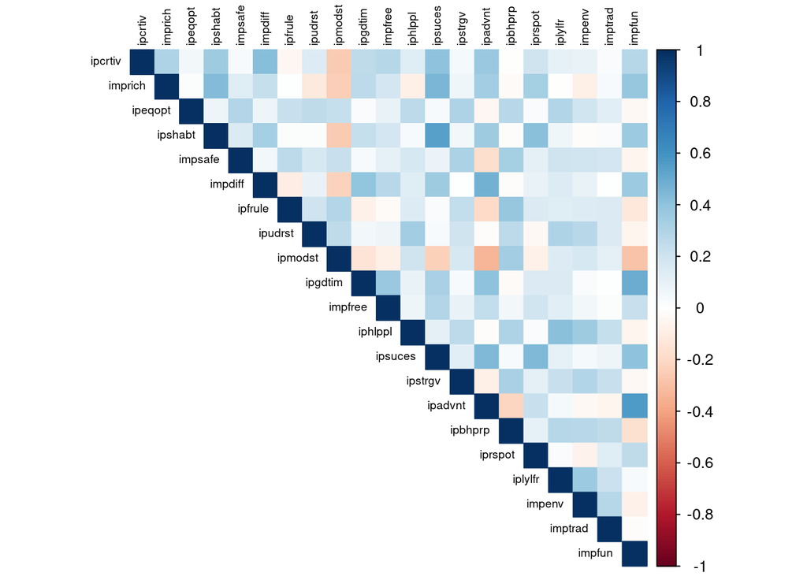

```r
cor_matrix <- cor(est, use = "complete.obs")
corrplot(cor_matrix, method = "color", type = "upper",
         tl.cex = 0.6, tl.col = "black")
```

```r
det(cor_matrix)
```

```
## [1] 0.003976691
```

#### 3.4 Sampling adequacy

```r
KMO(est)
```

```
## Kaiser-Meyer-Olkin factor adequacy
## Call: KMO(r = est)
## Overall MSA =  0.86
## MSA for each item =
## ipcrtiv imprich ipeqopt ipshabt impsafe impdiff ipfrule ipudrst ipmodst ipgdtim
##    0.88    0.89    0.86    0.87    0.83    0.87    0.85    0.85    0.88    0.84
## impfree iphlppl ipsuces ipstrgv ipadvnt ipbhprp iprspot iplylfr  impenv imptrad
##    0.86    0.85    0.88    0.88    0.87    0.88    0.81    0.86    0.85    0.85
##  impfun
##    0.87
```

#### 3.5 Sphericity

```r
cortest.bartlett(est)
```

```
## R was not square, finding R from data
```

```
## $chisq
## [1] 9872.688
##
## $p.value
## [1] 0
##
## $df
## [1] 210
```

### 4. Determinig the number of factors

```r
ev <- eigen(cor(est))
ev$values
```

```
##  [1] 4.2509646 3.5932790 1.5759077 1.0474071 0.9388261 0.8916045 0.8375669
##  [8] 0.7483126 0.7297168 0.6946515 0.6586820 0.6295134 0.6087827 0.5807315
## [15] 0.5444672 0.5109194 0.4932874 0.4578522 0.4432755 0.4095270 0.3547250
```

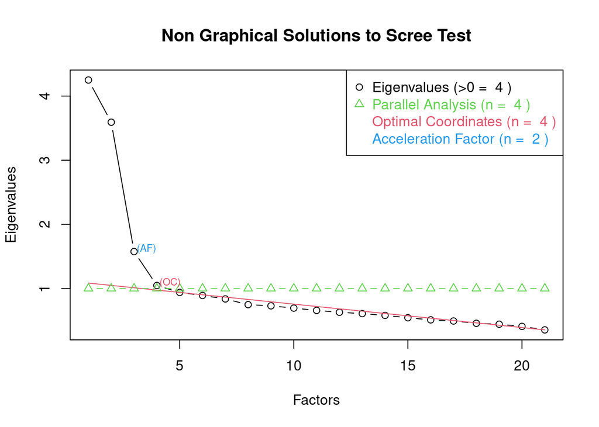

```r
nS <- nScree(x=ev$values, model = 'factors')
plotnScree(nS)
```

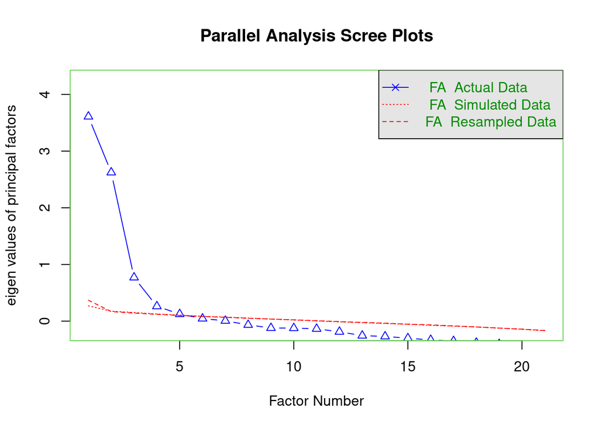

```
## Parallel analysis suggests that the number of factors =  5  and the number of components =  NA
```

```r
fa.parallel(est, fm = 'ml', fa = 'fa')
```

##### *Eigenvalues analysis shows 4 factors containig enough information (>1). Scree plot also shows 4 as an optimal number of factors and parallel analysis suggests that the number of factors should be 5. I will try to conduct the analysis with 4 and 5 factors.*

### 5. Conducting EFA

```r
fa1 = fa(est, nfactors = 4,fm = 'ml', rotate = 'varimax')
fa1
```

```
## Factor Analysis using method =  ml
## Call: fa(r = est, nfactors = 4, rotate = "varimax", fm = "ml")
## Standardized loadings (pattern matrix) based upon correlation matrix
##           ML3   ML2   ML4   ML1   h2   u2 com
## ipcrtiv  0.48  0.26 -0.18  0.22 0.38 0.62 2.3
## imprich  0.57 -0.15  0.09  0.26 0.42 0.58 1.6
## ipeqopt  0.02  0.36  0.32  0.05 0.24 0.76 2.0
## ipshabt  0.70  0.02  0.04  0.16 0.51 0.49 1.1
## impsafe  0.12  0.22  0.49  0.00 0.31 0.69 1.5
## impdiff  0.35  0.27 -0.22  0.42 0.42 0.58 3.3
## ipfrule  0.02  0.15  0.52 -0.11 0.30 0.70 1.3
## ipudrst -0.05  0.51  0.16  0.05 0.29 0.71 1.2
## ipmodst -0.36  0.21  0.46 -0.12 0.40 0.60 2.5
## ipgdtim  0.17  0.08 -0.01  0.71 0.55 0.45 1.1
## impfree  0.23  0.13  0.04  0.37 0.21 0.79 2.0
## iphlppl  0.02  0.62  0.15  0.04 0.41 0.59 1.1
## ipsuces  0.71  0.10  0.04  0.26 0.58 0.42 1.3
## ipstrgv  0.09  0.33  0.40  0.01 0.28 0.72 2.1
## ipadvnt  0.44  0.03 -0.34  0.51 0.56 0.44 2.7
## ipbhprp -0.01  0.37  0.54 -0.06 0.43 0.57 1.8
## iprspot  0.55 -0.10  0.27  0.10 0.39 0.61 1.6
## iplylfr  0.01  0.55  0.18  0.16 0.36 0.64 1.4
## impenv  -0.03  0.56  0.13  0.00 0.33 0.67 1.1
## imptrad  0.07  0.29  0.25 -0.03 0.15 0.85 2.1
## impfun   0.38 -0.11 -0.13  0.61 0.55 0.45 1.9
##
##                        ML3  ML2  ML4  ML1
## SS loadings           2.55 2.05 1.74 1.74
## Proportion Var        0.12 0.10 0.08 0.08
## Cumulative Var        0.12 0.22 0.30 0.38
## Proportion Explained  0.32 0.25 0.22 0.22
## Cumulative Proportion 0.32 0.57 0.78 1.00
##
## Mean item complexity =  1.8
## Test of the hypothesis that 4 factors are sufficient.
##
## df null model =  210  with the objective function =  5.53 with Chi Square =  9872.69
## df of  the model are 132  and the objective function was  0.38
##
## The root mean square of the residuals (RMSR) is  0.03
## The df corrected root mean square of the residuals is  0.03
##
## The harmonic n.obs is  1795 with the empirical chi square  552.55  with prob <  8e-53
## The total n.obs was  1795  with Likelihood Chi Square =  669.79  with prob <  7.1e-73
##
## Tucker Lewis Index of factoring reliability =  0.911
## RMSEA index =  0.048  and the 90 % confidence intervals are  0.044 0.051
## BIC =  -319.26
## Fit based upon off diagonal values = 0.99
## Measures of factor score adequacy
##                                                    ML3  ML2  ML4  ML1
## Correlation of (regression) scores with factors   0.87 0.84 0.82 0.81
## Multiple R square of scores with factors          0.76 0.71 0.67 0.66
## Minimum correlation of possible factor scores     0.51 0.41 0.33 0.32
```

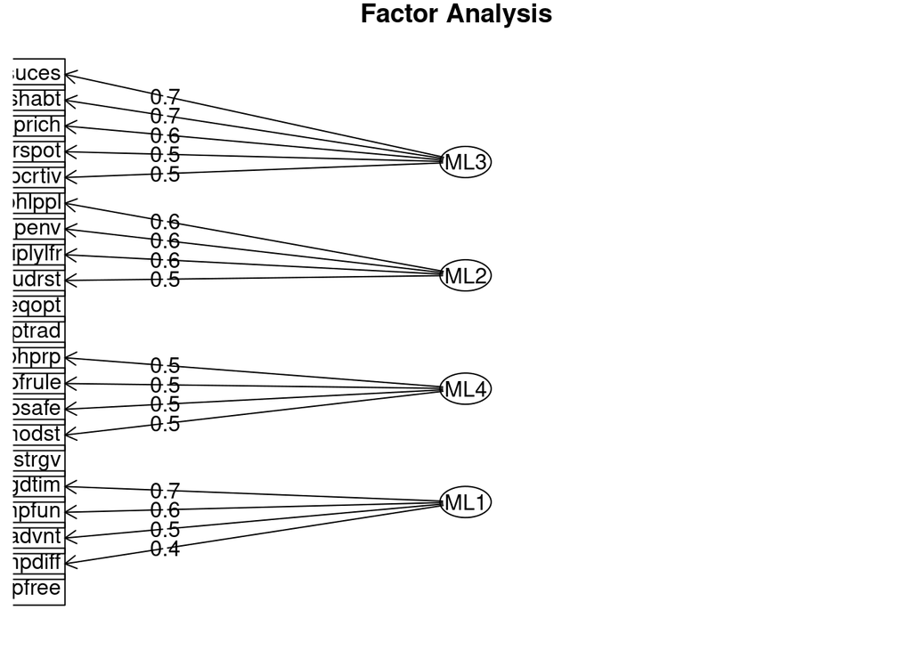

```r
fa.diagram(fa1, cut = 0.4)
```

```r
print(fa1$loadings,cutoff = 0.4)
```

```
##
## Loadings:
##         ML3    ML2    ML4    ML1
## ipcrtiv  0.485
## imprich  0.567
## ipeqopt
## ipshabt  0.698
## impsafe                0.491
## impdiff                       0.421
## ipfrule                0.520
## ipudrst         0.509
## ipmodst                0.461
## ipgdtim                       0.715
## impfree
## iphlppl         0.619
## ipsuces  0.709
## ipstrgv
## ipadvnt  0.436                0.509
## ipbhprp                0.540
## iprspot  0.549
## iplylfr         0.552
## impenv          0.561
## imptrad
## impfun                        0.611
##
##                  ML3   ML2   ML4   ML1
## SS loadings    2.549 2.052 1.740 1.737
## Proportion Var 0.121 0.098 0.083 0.083
## Cumulative Var 0.121 0.219 0.302 0.385
```

```r
fa2 = fa(est, nfactors = 4, fm = 'ml',rotate = 'oblimin')
fa2
```

```
## Factor Analysis using method =  ml
## Call: fa(r = est, nfactors = 4, rotate = "oblimin", fm = "ml")
## Standardized loadings (pattern matrix) based upon correlation matrix
##           ML3   ML2   ML1   ML4   h2   u2 com
## ipcrtiv  0.41  0.30  0.05 -0.28 0.38 0.62 2.7
## imprich  0.55 -0.18  0.17  0.08 0.42 0.58 1.5
## ipeqopt  0.03  0.33  0.05  0.27 0.24 0.76 2.0
## ipshabt  0.72  0.02 -0.02 -0.04 0.51 0.49 1.0
## impsafe  0.20  0.16  0.00  0.46 0.31 0.69 1.6
## impdiff  0.18  0.30  0.33 -0.27 0.42 0.58 3.5
## ipfrule  0.14  0.08 -0.08  0.50 0.30 0.70 1.3
## ipudrst -0.07  0.51  0.02  0.09 0.29 0.71 1.1
## ipmodst -0.29  0.14  0.00  0.49 0.40 0.60 1.8
## ipgdtim -0.08  0.04  0.79  0.07 0.55 0.45 1.0
## impfree  0.11  0.11  0.37  0.05 0.21 0.79 1.4
## iphlppl  0.00  0.63 -0.03  0.05 0.41 0.59 1.0
## ipsuces  0.69  0.09  0.10 -0.04 0.58 0.42 1.1
## ipstrgv  0.15  0.29 -0.01  0.35 0.28 0.72 2.3
## ipadvnt  0.23  0.06  0.43 -0.34 0.56 0.44 2.6
## ipbhprp  0.08  0.30 -0.05  0.49 0.43 0.57 1.7
## iprspot  0.62 -0.14  0.01  0.24 0.39 0.61 1.4
## iplylfr -0.04  0.54  0.13  0.11 0.36 0.64 1.2
## impenv  -0.04  0.57 -0.05  0.04 0.33 0.67 1.0
## imptrad  0.12  0.27 -0.06  0.19 0.15 0.85 2.4
## impfun   0.18 -0.12  0.61 -0.07 0.55 0.45 1.3
##
##                        ML3  ML2  ML1  ML4
## SS loadings           2.39 2.12 1.80 1.76
## Proportion Var        0.11 0.10 0.09 0.08
## Cumulative Var        0.11 0.21 0.30 0.38
## Proportion Explained  0.30 0.26 0.22 0.22
## Cumulative Proportion 0.30 0.56 0.78 1.00
##
##  With factor correlations of
##       ML3  ML2   ML1   ML4
## ML3  1.00 0.10  0.53 -0.11
## ML2  0.10 1.00  0.15  0.28
## ML1  0.53 0.15  1.00 -0.29
## ML4 -0.11 0.28 -0.29  1.00
##
## Mean item complexity =  1.7
## Test of the hypothesis that 4 factors are sufficient.
##
## df null model =  210  with the objective function =  5.53 with Chi Square =  9872.69
## df of  the model are 132  and the objective function was  0.38
##
## The root mean square of the residuals (RMSR) is  0.03
## The df corrected root mean square of the residuals is  0.03
##
## The harmonic n.obs is  1795 with the empirical chi square  552.55  with prob <  8e-53
## The total n.obs was  1795  with Likelihood Chi Square =  669.79  with prob <  7.1e-73
##
## Tucker Lewis Index of factoring reliability =  0.911
## RMSEA index =  0.048  and the 90 % confidence intervals are  0.044 0.051
## BIC =  -319.26
## Fit based upon off diagonal values = 0.99
## Measures of factor score adequacy
##                                                    ML3  ML2  ML1  ML4
## Correlation of (regression) scores with factors   0.91 0.87 0.89 0.85
## Multiple R square of scores with factors          0.82 0.76 0.79 0.73
## Minimum correlation of possible factor scores     0.64 0.52 0.57 0.46
```

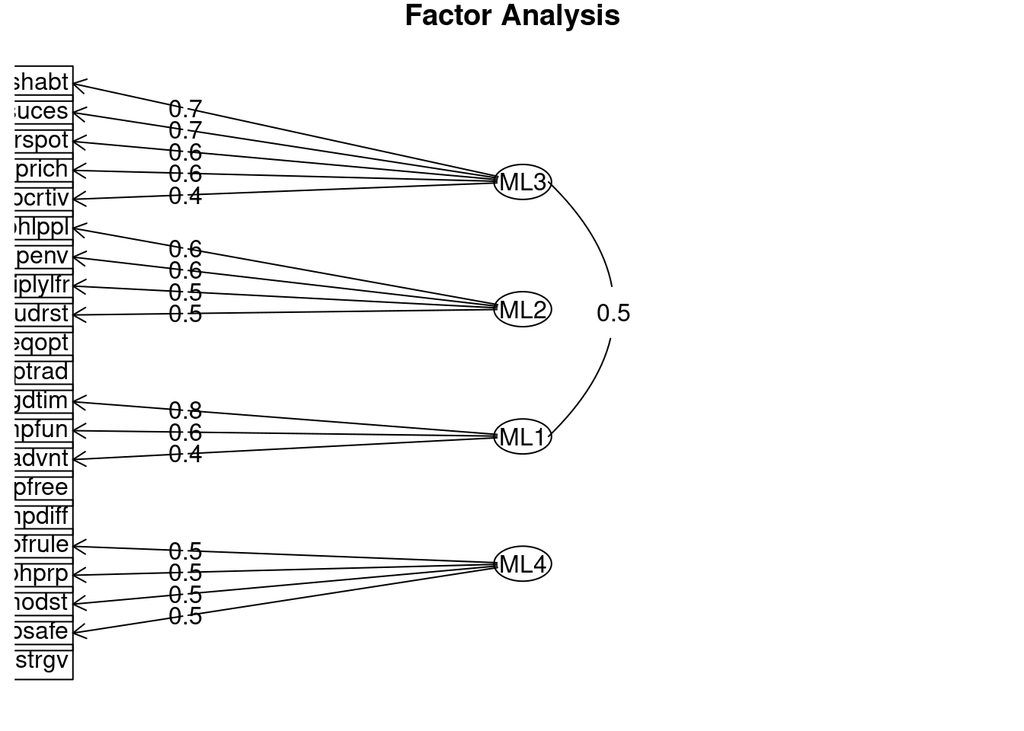

```r
fa.diagram(fa2, cut = 0.4)
```

```r
print(fa2$loadings,cutoff = 0.4)
```

```
##
## Loadings:
##         ML3    ML2    ML1    ML4
## ipcrtiv  0.413
## imprich  0.551
## ipeqopt
## ipshabt  0.718
## impsafe                       0.460
## impdiff
## ipfrule                       0.503
## ipudrst         0.507
## ipmodst                       0.486
## ipgdtim                0.791
## impfree
## iphlppl         0.627
## ipsuces  0.686
## ipstrgv
## ipadvnt                0.427
## ipbhprp                       0.495
## iprspot  0.616
## iplylfr         0.544
## impenv          0.570
## imptrad
## impfun                 0.614
##
##                  ML3   ML2   ML1   ML4
## SS loadings    2.173 1.954 1.505 1.554
## Proportion Var 0.103 0.093 0.072 0.074
## Cumulative Var 0.103 0.197 0.268 0.342
```

```r
fa3 = fa(est, nfactors = 4, fm = 'ml',rotate = 'promax')
fa3
```

```
## Factor Analysis using method =  ml
## Call: fa(r = est, nfactors = 4, rotate = "promax", fm = "ml")
## Standardized loadings (pattern matrix) based upon correlation matrix
##           ML3   ML2   ML4   ML1   h2   u2 com
## ipcrtiv  0.48  0.31 -0.23 -0.03 0.38 0.62 2.2
## imprich  0.57 -0.24  0.16  0.15 0.42 0.58 1.7
## ipeqopt -0.01  0.29  0.29  0.06 0.24 0.76 2.1
## ipshabt  0.78 -0.02  0.05 -0.09 0.51 0.49 1.0
## impsafe  0.15  0.09  0.51  0.03 0.31 0.69 1.2
## impdiff  0.21  0.30 -0.25  0.28 0.42 0.58 3.8
## ipfrule  0.08  0.01  0.54 -0.04 0.30 0.70 1.1
## ipudrst -0.10  0.50  0.09  0.02 0.29 0.71 1.1
## ipmodst -0.39  0.10  0.47  0.08 0.40 0.60 2.1
## ipgdtim -0.14 -0.03  0.07  0.85 0.55 0.45 1.1
## impfree  0.09  0.06  0.07  0.38 0.21 0.79 1.3
## iphlppl -0.02  0.63  0.06 -0.05 0.41 0.59 1.0
## ipsuces  0.74  0.04  0.06  0.03 0.58 0.42 1.0
## ipstrgv  0.10  0.24  0.39  0.01 0.28 0.72 1.8
## ipadvnt  0.28  0.05 -0.32  0.39 0.56 0.44 2.8
## ipbhprp  0.01  0.24  0.53 -0.01 0.43 0.57 1.4
## iprspot  0.63 -0.21  0.33 -0.01 0.39 0.61 1.8
## iplylfr -0.08  0.53  0.11  0.13 0.36 0.64 1.3
## impenv  -0.06  0.58  0.04 -0.07 0.33 0.67 1.1
## imptrad  0.10  0.24  0.22 -0.07 0.15 0.85 2.5
## impfun   0.17 -0.18 -0.04  0.63 0.55 0.45 1.3
##
##                        ML3  ML2  ML4  ML1
## SS loadings           2.57 1.96 1.87 1.67
## Proportion Var        0.12 0.09 0.09 0.08
## Cumulative Var        0.12 0.22 0.30 0.38
## Proportion Explained  0.32 0.24 0.23 0.21
## Cumulative Proportion 0.32 0.56 0.79 1.00
##
##  With factor correlations of
##       ML3  ML2   ML4   ML1
## ML3  1.00 0.18 -0.13  0.66
## ML2  0.18 1.00  0.35  0.27
## ML4 -0.13 0.35  1.00 -0.25
## ML1  0.66 0.27 -0.25  1.00
##
## Mean item complexity =  1.7
## Test of the hypothesis that 4 factors are sufficient.
##
## df null model =  210  with the objective function =  5.53 with Chi Square =  9872.69
## df of  the model are 132  and the objective function was  0.38
##
## The root mean square of the residuals (RMSR) is  0.03
## The df corrected root mean square of the residuals is  0.03
##
## The harmonic n.obs is  1795 with the empirical chi square  552.55  with prob <  8e-53
## The total n.obs was  1795  with Likelihood Chi Square =  669.79  with prob <  7.1e-73
##
## Tucker Lewis Index of factoring reliability =  0.911
## RMSEA index =  0.048  and the 90 % confidence intervals are  0.044 0.051
## BIC =  -319.26
## Fit based upon off diagonal values = 0.99
## Measures of factor score adequacy
##                                                    ML3  ML2  ML4 ML1
## Correlation of (regression) scores with factors   0.92 0.87 0.87 0.9
## Multiple R square of scores with factors          0.85 0.76 0.75 0.8
## Minimum correlation of possible factor scores     0.69 0.52 0.51 0.6
```

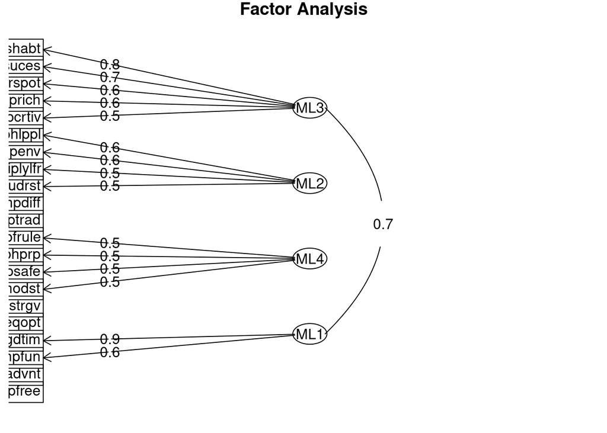

```r
fa.diagram(fa3, cut = 0.4)
```

```r
print(fa3$loadings,cutoff = 0.4)
```

```
##
## Loadings:
##         ML3    ML2    ML4    ML1
## ipcrtiv  0.481
## imprich  0.574
## ipeqopt
## ipshabt  0.782
## impsafe                0.509
## impdiff
## ipfrule                0.544
## ipudrst         0.503
## ipmodst                0.468
## ipgdtim                       0.850
## impfree
## iphlppl         0.629
## ipsuces  0.739
## ipstrgv
## ipadvnt
## ipbhprp                0.530
## iprspot  0.630
## iplylfr         0.528
## impenv          0.577
## imptrad
## impfun                        0.629
##
##                  ML3   ML2   ML4   ML1
## SS loadings    2.514 1.866 1.741 1.566
## Proportion Var 0.120 0.089 0.083 0.075
## Cumulative Var 0.120 0.209 0.292 0.366
```

```r
fa4 = fa(est, nfactors = 5,fm = 'ml', rotate = 'varimax')
fa4
```

```
## Factor Analysis using method =  ml
## Call: fa(r = est, nfactors = 5, rotate = "varimax", fm = "ml")
## Standardized loadings (pattern matrix) based upon correlation matrix
##           ML2   ML1   ML3   ML5   ML4   h2   u2 com
## ipcrtiv  0.15  0.31  0.32 -0.03  0.43 0.41 0.59 3.1
## imprich -0.14  0.33  0.51  0.17  0.11 0.43 0.57 2.3
## ipeqopt  0.40  0.05  0.00  0.30  0.00 0.26 0.74 1.9
## ipshabt  0.00  0.26  0.61  0.12  0.26 0.52 0.48 1.9
## impsafe  0.28  0.00  0.12  0.62 -0.01 0.48 0.52 1.5
## impdiff  0.14  0.52  0.14  0.00  0.41 0.47 0.53 2.2
## ipfrule  0.32 -0.15  0.15  0.28 -0.26 0.29 0.71 3.9
## ipudrst  0.53  0.05 -0.07  0.07  0.05 0.29 0.71 1.1
## ipmodst  0.36 -0.21 -0.21  0.23 -0.36 0.40 0.60 4.0
## ipgdtim  0.07  0.70  0.09  0.02  0.01 0.51 0.49 1.1
## impfree  0.11  0.39  0.16  0.10  0.10 0.21 0.79 1.8
## iphlppl  0.65  0.04  0.00 -0.01  0.07 0.43 0.57 1.0
## ipsuces  0.11  0.35  0.66 -0.02  0.18 0.60 0.40 1.8
## ipstrgv  0.42  0.00  0.13  0.28 -0.08 0.28 0.72 2.0
## ipadvnt -0.07  0.61  0.29 -0.27  0.23 0.59 0.41 2.2
## ipbhprp  0.52 -0.11  0.09  0.31 -0.20 0.42 0.58 2.1
## iprspot  0.04  0.12  0.66  0.05 -0.14 0.47 0.53 1.2
## iplylfr  0.57  0.16 -0.02  0.06  0.03 0.36 0.64 1.2
## impenv   0.56  0.01 -0.07  0.05  0.08 0.33 0.67 1.1
## imptrad  0.37 -0.04  0.13  0.07 -0.10 0.17 0.83 1.5
## impfun  -0.13  0.68  0.30 -0.10  0.01 0.58 0.42 1.5
##
##                        ML2  ML1  ML3  ML5  ML4
## SS loadings           2.52 2.27 1.95 0.94 0.81
## Proportion Var        0.12 0.11 0.09 0.04 0.04
## Cumulative Var        0.12 0.23 0.32 0.37 0.40
## Proportion Explained  0.30 0.27 0.23 0.11 0.10
## Cumulative Proportion 0.30 0.56 0.79 0.90 1.00
##
## Mean item complexity =  1.9
## Test of the hypothesis that 5 factors are sufficient.
##
## df null model =  210  with the objective function =  5.53 with Chi Square =  9872.69
## df of  the model are 115  and the objective function was  0.28
##
## The root mean square of the residuals (RMSR) is  0.02
## The df corrected root mean square of the residuals is  0.03
##
## The harmonic n.obs is  1795 with the empirical chi square  401.11  with prob <  2.5e-33
## The total n.obs was  1795  with Likelihood Chi Square =  498.6  with prob <  3.4e-49
##
## Tucker Lewis Index of factoring reliability =  0.927
## RMSEA index =  0.043  and the 90 % confidence intervals are  0.039 0.047
## BIC =  -363.07
## Fit based upon off diagonal values = 0.99
## Measures of factor score adequacy
##                                                    ML2  ML1  ML3  ML5   ML4
## Correlation of (regression) scores with factors   0.87 0.85 0.84 0.72  0.70
## Multiple R square of scores with factors          0.76 0.72 0.71 0.53  0.48
## Minimum correlation of possible factor scores     0.52 0.45 0.42 0.05 -0.03
```

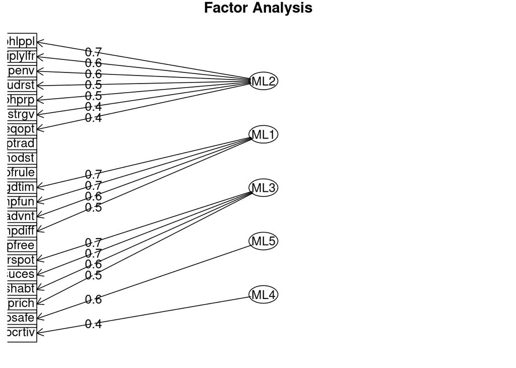

```r
fa.diagram(fa4, cut = 0.4)
```

```r
print(fa4$loadings,cutoff = 0.4)
```

```
##
## Loadings:
##         ML2    ML1    ML3    ML5    ML4
## ipcrtiv                              0.428
## imprich                0.507
## ipeqopt  0.405
## ipshabt                0.608
## impsafe                       0.623
## impdiff         0.517                0.412
## ipfrule
## ipudrst  0.528
## ipmodst
## ipgdtim         0.702
## impfree
## iphlppl  0.651
## ipsuces                0.655
## ipstrgv  0.421
## ipadvnt         0.609
## ipbhprp  0.517
## iprspot                0.660
## iplylfr  0.574
## impenv   0.561
## imptrad
## impfun          0.681
##
##                  ML2   ML1   ML3   ML5   ML4
## SS loadings    2.518 2.268 1.948 0.937 0.813
## Proportion Var 0.120 0.108 0.093 0.045 0.039
## Cumulative Var 0.120 0.228 0.321 0.365 0.404
```

```r
fa5 = fa(est, nfactors = 5, fm = 'ml',rotate = 'oblimin')
fa5
```

```
## Factor Analysis using method =  ml
## Call: fa(r = est, nfactors = 5, rotate = "oblimin", fm = "ml")
## Standardized loadings (pattern matrix) based upon correlation matrix
##           ML2   ML1   ML3   ML5   ML4   h2   u2 com
## ipcrtiv  0.18  0.06  0.24  0.00  0.46 0.41 0.59 1.9
## imprich -0.23  0.20  0.41  0.21  0.13 0.43 0.57 3.0
## ipeqopt  0.29  0.05 -0.04  0.32  0.01 0.26 0.74 2.1
## ipshabt -0.06  0.02  0.55  0.14  0.29 0.52 0.48 1.7
## impsafe  0.02  0.00  0.03  0.69  0.04 0.48 0.52 1.0
## impdiff  0.15  0.35 -0.03  0.06  0.44 0.47 0.53 2.2
## ipfrule  0.19 -0.10  0.21  0.25 -0.28 0.29 0.71 4.0
## ipudrst  0.52  0.02 -0.06  0.05  0.03 0.29 0.71 1.1
## ipmodst  0.26 -0.03 -0.15  0.20 -0.39 0.40 0.60 2.7
## ipgdtim  0.05  0.76 -0.08  0.08 -0.03 0.51 0.49 1.1
## impfree  0.07  0.35  0.05  0.14  0.09 0.21 0.79 1.6
## iphlppl  0.68 -0.03  0.04 -0.05  0.04 0.43 0.57 1.0
## ipsuces  0.11  0.12  0.63 -0.04  0.16 0.60 0.40 1.3
## ipstrgv  0.30 -0.01  0.13  0.27 -0.09 0.28 0.72 2.6
## ipadvnt  0.05  0.49  0.18 -0.26  0.19 0.59 0.41 2.2
## ipbhprp  0.39 -0.07  0.13  0.28 -0.22 0.42 0.58 2.9
## iprspot -0.01  0.02  0.71  0.00 -0.18 0.47 0.53 1.1
## iplylfr  0.56  0.14 -0.03  0.05  0.01 0.36 0.64 1.1
## impenv   0.56 -0.04 -0.05  0.03  0.07 0.33 0.67 1.1
## imptrad  0.34 -0.05  0.19  0.02 -0.13 0.17 0.83 1.9
## impfun  -0.10  0.68  0.15 -0.07 -0.04 0.58 0.42 1.2
##
##                        ML2  ML1  ML3  ML5  ML4
## SS loadings           2.22 1.95 1.89 1.22 1.21
## Proportion Var        0.11 0.09 0.09 0.06 0.06
## Cumulative Var        0.11 0.20 0.29 0.35 0.40
## Proportion Explained  0.26 0.23 0.22 0.14 0.14
## Cumulative Proportion 0.26 0.49 0.71 0.86 1.00
##
##  With factor correlations of
##       ML2   ML1  ML3   ML5   ML4
## ML2  1.00  0.03 0.02  0.43 -0.03
## ML1  0.03  1.00 0.46 -0.08  0.49
## ML3  0.02  0.46 1.00  0.17  0.29
## ML5  0.43 -0.08 0.17  1.00 -0.18
## ML4 -0.03  0.49 0.29 -0.18  1.00
##
## Mean item complexity =  1.8
## Test of the hypothesis that 5 factors are sufficient.
##
## df null model =  210  with the objective function =  5.53 with Chi Square =  9872.69
## df of  the model are 115  and the objective function was  0.28
##
## The root mean square of the residuals (RMSR) is  0.02
## The df corrected root mean square of the residuals is  0.03
##
## The harmonic n.obs is  1795 with the empirical chi square  401.11  with prob <  2.5e-33
## The total n.obs was  1795  with Likelihood Chi Square =  498.6  with prob <  3.4e-49
##
## Tucker Lewis Index of factoring reliability =  0.927
## RMSEA index =  0.043  and the 90 % confidence intervals are  0.039 0.047
## BIC =  -363.07
## Fit based upon off diagonal values = 0.99
## Measures of factor score adequacy
##                                                    ML2  ML1  ML3  ML5  ML4
## Correlation of (regression) scores with factors   0.88 0.89 0.89 0.83 0.82
## Multiple R square of scores with factors          0.78 0.80 0.78 0.68 0.67
## Minimum correlation of possible factor scores     0.55 0.60 0.57 0.36 0.33
```

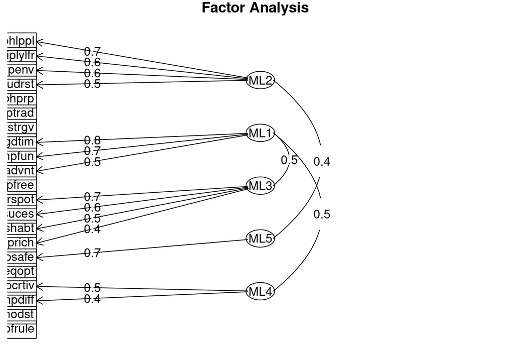

```r
fa.diagram(fa5, cut = 0.4)
```

```r
print(fa5$loadings,cutoff = 0.4)
```

```
##
## Loadings:
##         ML2    ML1    ML3    ML5    ML4
## ipcrtiv                              0.460
## imprich                0.413
## ipeqopt
## ipshabt                0.549
## impsafe                       0.687
## impdiff                              0.440
## ipfrule
## ipudrst  0.517
## ipmodst
## ipgdtim         0.760
## impfree
## iphlppl  0.676
## ipsuces                0.629
## ipstrgv
## ipadvnt         0.489
## ipbhprp
## iprspot                0.712
## iplylfr  0.562
## impenv   0.562
## imptrad
## impfun          0.683
##
##                  ML2   ML1   ML3   ML5   ML4
## SS loadings    2.048 1.634 1.647 0.998 0.927
## Proportion Var 0.098 0.078 0.078 0.048 0.044
## Cumulative Var 0.098 0.175 0.254 0.301 0.345
```

```r
fa6 = fa(est, nfactors = 5, fm = 'ml',rotate = 'promax')
fa6
```

```
## Factor Analysis using method =  ml
## Call: fa(r = est, nfactors = 5, rotate = "promax", fm = "ml")
## Standardized loadings (pattern matrix) based upon correlation matrix
##           ML2   ML1   ML3   ML4   ML5   h2   u2 com
## ipcrtiv  0.20 -0.01  0.23  0.55  0.03 0.41 0.59 1.6
## imprich -0.27  0.18  0.43  0.14  0.22 0.43 0.57 2.9
## ipeqopt  0.28  0.05 -0.08  0.03  0.31 0.26 0.74 2.2
## ipshabt -0.06 -0.05  0.56  0.37  0.15 0.52 0.48 2.0
## impsafe -0.04 -0.02  0.00  0.05  0.73 0.48 0.52 1.0
## impdiff  0.16  0.30 -0.04  0.48  0.10 0.47 0.53 2.1
## ipfrule  0.18 -0.07  0.19 -0.28  0.18 0.29 0.71 3.6
## ipudrst  0.56  0.02 -0.11  0.08  0.00 0.29 0.71 1.1
## ipmodst  0.26  0.04 -0.18 -0.43  0.12 0.40 0.60 2.3
## ipgdtim  0.02  0.80 -0.09 -0.10  0.02 0.51 0.49 1.1
## impfree  0.06  0.35  0.04  0.09  0.12 0.21 0.79 1.5
## iphlppl  0.74 -0.03 -0.01  0.12 -0.13 0.43 0.57 1.1
## ipsuces  0.14  0.09  0.63  0.24 -0.09 0.60 0.40 1.5
## ipstrgv  0.31  0.00  0.10 -0.06  0.22 0.28 0.72 2.1
## ipadvnt  0.06  0.48  0.19  0.20 -0.30 0.59 0.41 2.5
## ipbhprp  0.40 -0.05  0.09 -0.19  0.20 0.42 0.58 2.2
## iprspot  0.00  0.03  0.73 -0.15 -0.11 0.47 0.53 1.1
## iplylfr  0.60  0.15 -0.07  0.04 -0.02 0.36 0.64 1.2
## impenv   0.61 -0.05 -0.09  0.13 -0.02 0.33 0.67 1.2
## imptrad  0.37 -0.04  0.16 -0.09 -0.05 0.17 0.83 1.6
## impfun  -0.12  0.72  0.17 -0.09 -0.14 0.58 0.42 1.3
##
##                        ML2  ML1  ML3  ML4  ML5
## SS loadings           2.36 1.87 1.86 1.34 1.05
## Proportion Var        0.11 0.09 0.09 0.06 0.05
## Cumulative Var        0.11 0.20 0.29 0.35 0.40
## Proportion Explained  0.28 0.22 0.22 0.16 0.12
## Cumulative Proportion 0.28 0.50 0.72 0.88 1.00
##
##  With factor correlations of
##       ML2  ML1  ML3   ML4   ML5
## ML2  1.00 0.06 0.13 -0.21  0.60
## ML1  0.06 1.00 0.45  0.59  0.04
## ML3  0.13 0.45 1.00  0.20  0.32
## ML4 -0.21 0.59 0.20  1.00 -0.30
## ML5  0.60 0.04 0.32 -0.30  1.00
##
## Mean item complexity =  1.8
## Test of the hypothesis that 5 factors are sufficient.
##
## df null model =  210  with the objective function =  5.53 with Chi Square =  9872.69
## df of  the model are 115  and the objective function was  0.28
##
## The root mean square of the residuals (RMSR) is  0.02
## The df corrected root mean square of the residuals is  0.03
##
## The harmonic n.obs is  1795 with the empirical chi square  401.11  with prob <  2.5e-33
## The total n.obs was  1795  with Likelihood Chi Square =  498.6  with prob <  3.4e-49
##
## Tucker Lewis Index of factoring reliability =  0.927
## RMSEA index =  0.043  and the 90 % confidence intervals are  0.039 0.047
## BIC =  -363.07
## Fit based upon off diagonal values = 0.99
## Measures of factor score adequacy
##                                                    ML2  ML1  ML3  ML4  ML5
## Correlation of (regression) scores with factors   0.89 0.90 0.88 0.85 0.84
## Multiple R square of scores with factors          0.80 0.81 0.78 0.72 0.71
## Minimum correlation of possible factor scores     0.60 0.62 0.56 0.45 0.41
```

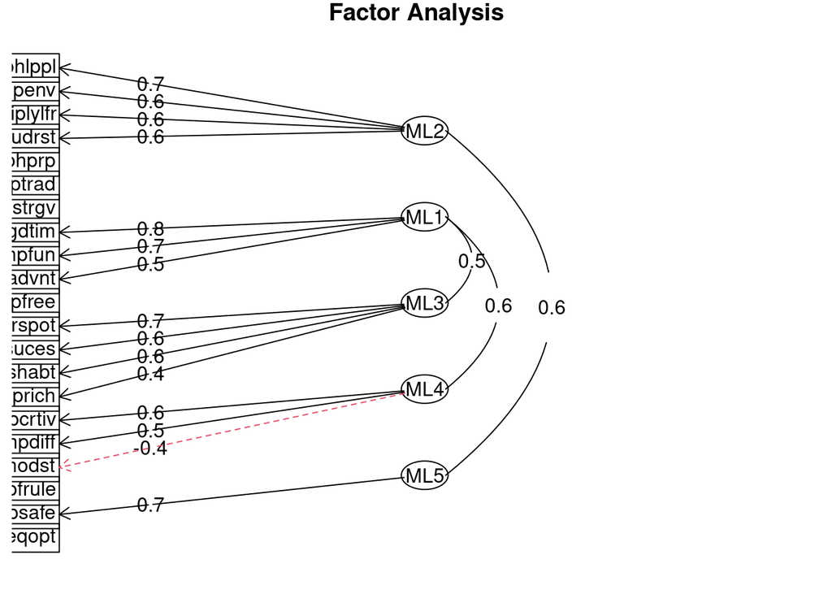

```r
fa.diagram(fa6, cut = 0.4)
```

```r
print(fa6$loadings,cutoff = 0.4)
```

```
##
## Loadings:
##         ML2    ML1    ML3    ML4    ML5
## ipcrtiv                       0.551
## imprich                0.429
## ipeqopt
## ipshabt                0.556
## impsafe                              0.731
## impdiff                       0.481
## ipfrule
## ipudrst  0.556
## ipmodst                      -0.431
## ipgdtim         0.803
## impfree
## iphlppl  0.741
## ipsuces                0.632
## ipstrgv
## ipadvnt         0.482
## ipbhprp
## iprspot                0.725
## iplylfr  0.602
## impenv   0.610
## imptrad
## impfun          0.716
##
##                  ML2   ML1   ML3   ML4   ML5
## SS loadings    2.354 1.683 1.694 1.192 1.010
## Proportion Var 0.112 0.080 0.081 0.057 0.048
## Cumulative Var 0.112 0.192 0.273 0.330 0.378
```

##### *Models with 5 factors are slightly better statistically than models with 4 factors (TLI is higher (0.927 > 0.911), RMSEA is lower (0.043 < 0.048) and BIC is also lower (-363 < -319)). In general all the metrics are okay for each model. The problem with 5 factor models is that they have weak factors with 1-2 variables with each rotation method. I choose the fa2 with 4 factors and oblimin rotation method. Models with 4 factors are better interpreted. Factors division aligns with the Schwartz theory of basic human values. Model with oblimin rotation is the best choice because it has no cross-loadings and factors consist of at least 3 variables with mostly similar loadings. Moreover, chosen model shows that openness to change (ML1) and self-enhancement (ML3) are positively correlated (0.53), as well as self-transcendence (ML2) and conservation (ML4) (0.28), which again aligns with Schwartz theory (Schwartz, S. H., 1992). Below is the interpretation of factors:*

##### *ML1 - Openness to Change*

- *Important to have a good time*
- *Important to seek fun and things that give pleasure*
- *Important to seek adventures and have an exciting life*

##### *ML2 - Self-Transcendence*

- *Important to help people and care for others well-being*
- *Important to care for nature and environment*
- *Important to be loyal to friends and devote to people close*
- *Important to understand different people*

##### *ML3 - Self-Enhancement*

- *Important to show abilities and be admired*
- *Important to be successful and that people recognize achievements*
- *Important to get respect from others*
- *Important to be rich, have money and expensive things*
- *Important to think new ideas and being creative*

##### *ML4 - Conservation*

- *Important to do what is told and follow rules*
- *Important to behave properly*
- *Important to live in secure and safe surroundings*
- *Important to be humble and modest, not draw attention*

### 6. Making a model without some variables

```r
est_clean <- est %>%
  select(-ipeqopt, -impdiff, -impfree, -ipstrgv, -imptrad)

fa_final = fa(est_clean, nfactors = 4, fm = 'ml',rotate = 'oblimin')
fa_final
```

```
## Factor Analysis using method =  ml
## Call: fa(r = est_clean, nfactors = 4, rotate = "oblimin", fm = "ml")
## Standardized loadings (pattern matrix) based upon correlation matrix
##           ML3   ML2   ML1   ML4   h2   u2 com
## ipcrtiv  0.46  0.27  0.03 -0.25 0.35 0.65 2.2
## imprich  0.52 -0.17  0.18  0.09 0.42 0.58 1.5
## ipshabt  0.71 -0.01  0.00 -0.01 0.51 0.49 1.0
## impsafe  0.21  0.12 -0.06  0.44 0.28 0.72 1.6
## ipfrule  0.12  0.05 -0.07  0.53 0.33 0.67 1.1
## ipudrst -0.05  0.50  0.02  0.11 0.30 0.70 1.1
## ipmodst -0.30  0.15 -0.01  0.50 0.42 0.58 1.9
## ipgdtim -0.03  0.14  0.64  0.03 0.40 0.60 1.1
## iphlppl  0.04  0.64 -0.04  0.04 0.43 0.57 1.0
## ipsuces  0.70  0.10  0.09 -0.03 0.60 0.40 1.1
## ipadvnt  0.19  0.09  0.50 -0.29 0.56 0.44 2.0
## ipbhprp  0.09  0.27 -0.07  0.51 0.45 0.55 1.6
## iprspot  0.58 -0.13  0.03  0.24 0.38 0.62 1.4
## iplylfr -0.02  0.58  0.12  0.09 0.38 0.62 1.1
## impenv  -0.02  0.55 -0.04  0.04 0.32 0.68 1.0
## impfun   0.02 -0.07  0.82  0.02 0.68 0.32 1.0
##
##                        ML3  ML2  ML1  ML4
## SS loadings           2.16 1.66 1.60 1.37
## Proportion Var        0.14 0.10 0.10 0.09
## Cumulative Var        0.14 0.24 0.34 0.42
## Proportion Explained  0.32 0.24 0.24 0.20
## Cumulative Proportion 0.32 0.56 0.80 1.00
##
##  With factor correlations of
##       ML3  ML2   ML1   ML4
## ML3  1.00 0.07  0.57 -0.06
## ML2  0.07 1.00  0.02  0.29
## ML1  0.57 0.02  1.00 -0.30
## ML4 -0.06 0.29 -0.30  1.00
##
## Mean item complexity =  1.4
## Test of the hypothesis that 4 factors are sufficient.
##
## df null model =  120  with the objective function =  4.14 with Chi Square =  7405.45
## df of  the model are 62  and the objective function was  0.14
##
## The root mean square of the residuals (RMSR) is  0.02
## The df corrected root mean square of the residuals is  0.03
##
## The harmonic n.obs is  1795 with the empirical chi square  186.74  with prob <  2e-14
## The total n.obs was  1795  with Likelihood Chi Square =  244.96  with prob <  1.4e-23
##
## Tucker Lewis Index of factoring reliability =  0.951
## RMSEA index =  0.041  and the 90 % confidence intervals are  0.035 0.046
## BIC =  -219.59
## Fit based upon off diagonal values = 0.99
## Measures of factor score adequacy
##                                                    ML3  ML2  ML1  ML4
## Correlation of (regression) scores with factors   0.90 0.85 0.90 0.83
## Multiple R square of scores with factors          0.82 0.72 0.80 0.69
## Minimum correlation of possible factor scores     0.63 0.45 0.61 0.38
```

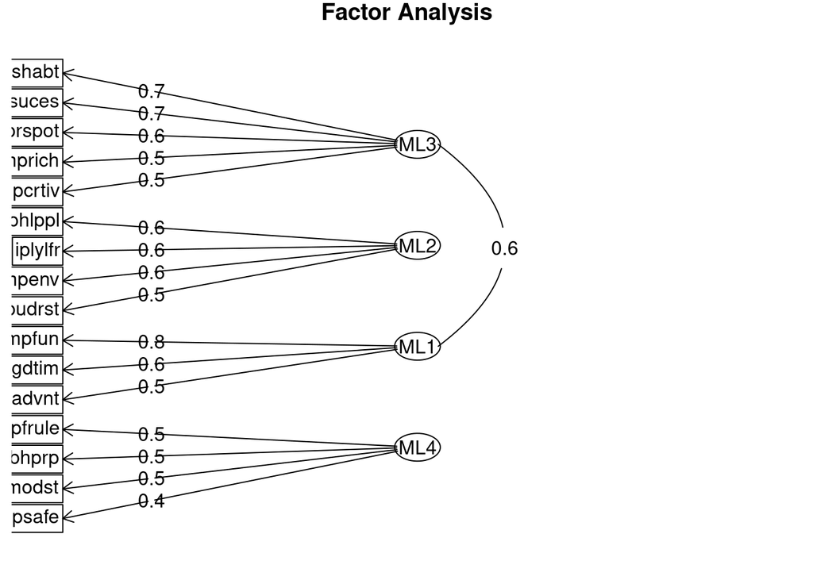

```r
fa.diagram(fa_final, cut = 0.4)
```

```r
print(fa_final$loadings,cutoff = 0.4)
```

```
##
## Loadings:
##         ML3    ML2    ML1    ML4
## ipcrtiv  0.456
## imprich  0.521
## ipshabt  0.714
## impsafe                       0.444
## ipfrule                       0.534
## ipudrst         0.504
## ipmodst                       0.496
## ipgdtim                0.638
## iphlppl         0.638
## ipsuces  0.698
## ipadvnt                0.496
## ipbhprp                       0.515
## iprspot  0.581
## iplylfr         0.575
## impenv          0.550
## impfun                 0.816
##
##                  ML3   ML2   ML1   ML4
## SS loadings    2.015 1.573 1.394 1.225
## Proportion Var 0.126 0.098 0.087 0.077
## Cumulative Var 0.126 0.224 0.311 0.388
```

##### *I deleted variables whcih were not included in any factor in fa2. New model is better because it has higher TLI (now it is > 95%!) and lower RMSEA. BIC is bigger but still negative. Factors stayed the same but there are significant changes in variables loadings in ML1: ipgdtim loading decreased (0.8 to 0.6) and impfun became the dominant variable (loading incresed from 0.6 to 0.8). Now all variables are included in factors and have loadings > 0.4. Correalarions between factors remained.*